# Homework #3

Hugo Lhuillier

08/03/2018

*Remember*: the cleaner and the more documented your code is, the more points you get.

## Exercice 1: factorial

Recall that the factorial of $n$, written $n!$, is defined as $n! = n \times (n - 1) \times \dots \times 2 \times 1$.

The `R` function `factorial(n)` compute the factorial of `n`. Using a `for` loop, write your own version of this function.

*Hint*: similar to the `sum` function we wrote in class.

```r
# load the testthat package to test our code
require("testthat")
factorial2 <- function(n){
  # computes the factorial of n
  k <- 1
  for (i in 1:n){
    k <- k * i
  }
  return(k)
}

# define our tests
test_that("Testing factorial2", {
  expect_true( factorial2(5) == factorial(5), "= base R function")
})
```

## Exercice 2: binomial distribution

The binomial random variable `Y \sim Bin(n,p)` repesents the number of successes in `n` binary trials, where the probability of success of each trial is the probability `p`.

Using only the `runif()` command - draw a number from the $(0,1)$ uniform distribution, write a function such `own_binomial` such that `own_binomial(n,p)` generates one draw of `Y`.

*Hint 1*: if $U \sim (0,1)$, and $p \in (0,1)$, then the expression `U < p` evalutes to `true` with probability `p`.

*Hint 2*: you will need to use both a `for` loop and a `if` statement.

```r
own_binomial <- function(n,p){
  count <- 0
  # draw n times from a (0,1) uniform distribution
  x     <- runif(n)
  for (i in 1:n){
    # count as a success only if the draw from the uniform (0,1) < p
    if (x[i] < p){
      count <- count + 1
    }
  }
  return(count)
}
```

## Exercice 3: binomial distribution (test)

The `R` function `rbinom(n,size,p)` generates `n` draws from a binomial distribution $Bin(size,p)$ *[i know, i was confused myself]*.

Using this function, and your function defined in exerice 2, test if your function is asymptotically correct.

*Hint*: you can look [here](https://www.r-bloggers.com/overlapping-histogram-in-r/) for some tricks on how to generate overlapping histrograms.

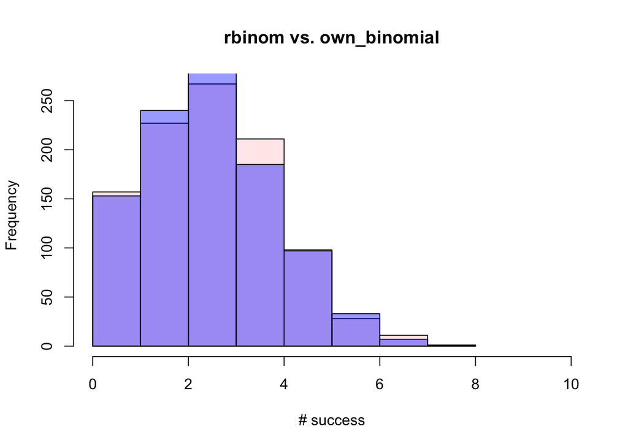

```r
size <- 10e2; n <- 10; p <- 0.3
bin  <- numeric(length(size))
for (i in 1:size){
  bin[i] <- own_binomial(n,p)
}
bin_r <- rbinom(size,n,p)
hist(bin, col=rgb(1,0,0,0.1),xlim=c(0,10), main = "rbinom vs. own_binomial", xlab = "# success", breaks = 10)
hist(bin_r, col=rgb(0,0,1,0.4), add=TRUE, breaks = 10)
```

## Exercice 4: random device

Write a program that compute one realization of the following random device:

1. flip an unbiased coin 30 times (*hint*: once again, using `runif`)
2. whenever 3 consecutive heads occur, add one dollar to your wealth (once again, very similar to how we computed the sum in class)
3. whenever 3 consecutive tails occur, remove one dollar from your wealth

```r
# define wealth and coin as vectors to store every value and plot the time series
# alternatively, could have simply defined wealth <- 0, coin <- 0
wealth      <- numeric(length= 30); coin <- numeric(length= 30)
# initialize the loop
coin[1]   <- runif(1)
wealth[1] <- 0
if (coin[1] > 0.5){
  count_head <- 1
  count_tail <- 0
} else {
  count_tail <- 1
  count_head <- 0
}

# loop over the 30 iterations
for (i in 2:30){
  coin[i] <- runif(1)
  # if the random draw > 0.5: head. otherwise: tail
  if (coin[i] > 0.5){
    count_head <- count_head + 1
    count_tail <- 0
  } else {
    count_tail <- count_tail + 1
    count_head <- 0
  }
  # if not interested in plotting the wealth, you can remove all the indexing, since you'll be working with a scalar
  if (count_tail == 3){
    print("- $$$")
    wealth[i] <- wealth[i-1] - 1
  } else if (count_head == 3){
    print("+ $$$")
    wealth[i] <- wealth[i-1] + 1
  } else {
    wealth[i] <- wealth[i-1]
  }
}
```

```
## [1] "- $$$"
## [1] "+ $$$"
## [1] "+ $$$"
```

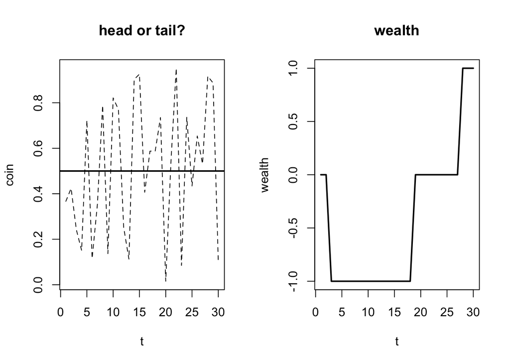

```r
par(mfrow=c(1,2))
# plot the coin process and the wealth process in two separate graphs
plot(coin, type = "l", xlab = "t", main = "head or tail?", lty = 2)
abline(h = 0.5, lty = 1, lwd = 2)
plot(wealth, lwd = 2, xlab = "t", type = "l", main = "wealth")
```